# Permutation-based significance testing

Author: Joyce Hsiao

Last updated: 2015-09-05 12:35:25

view source

```r
library(Biobase)

## Set working directories
dir <- "../"
figdir <- file.path(dir,"figures")
rdadir <- file.path(dir,"rdas")
datadir <- file.path(dir, "data")

## Use broman package for colors
require(broman)
crayon <- brocolors("crayons")

## Load customized packages
require(devtools)
require(Humanzee)
```

# Goal

Permutation-based significance testing for

1. The proportion of genes buffered at both Ribo and Protein levels among the genes that are buffered at the Ribo level
2. The proportion of genes buffered at both Ribo and Protein levels among the genes that are buffered at the Protein level

Note that here a gene is considered to be buffered at the Ribo level relative to the RNA level if there is a significance interaction of species and technology (RNA-Ribo) and if the absolute value of species difference at the RNA level is greater than the absolute value of species difference at the Ribo level.

# Approach

Perform the follow permutation 1,000 times:

For gene g, fix RNA data, select Ribo data from gene i, and select protein data from gene j. All selection was done with random sampling with replacement.

The source code for generating the permuted data sets and interaction results are recorded in *null-data-1000-midway.r*. We waited 8 hours approximately for 1000 permutations to complete for each interaction analysis.

```r
# Load data to compute fold changes
load(file.path(rdadir, "eSetRRP.rda"))

eSet.temp <- eSetRRP.log2[, eSetRRP.log2$species!="rhesus"]

fc.mat <- lapply( seq_along( c("human","chimp") ), function(i) {
  ii <- eSet.temp$species == c("human","chimp")[i]
  eSet.tt <- eSet.temp[, ii]
  emat <- lapply( seq_along( c("ribo","rna","protein") ), function(j) {
    jj <- eSet.tt$seqData == c("ribo","rna","protein")[j]
    rowMeans( exprs(eSet.tt[, jj] ), na.rm=TRUE )
  })
  emat <- do.call(cbind, emat)
  colnames(emat) <- c("ribo","rna","protein")
  return( data.frame(emat) )
})
names(fc.mat) <- c("human","chimp")

dmat_unnormed <- data.frame( ribo = fc.mat$human$ribo-fc.mat$chimp$ribo,
                             rna = fc.mat$human$rna-fc.mat$chimp$rna,
                             pro = fc.mat$human$protein-fc.mat$chimp$protein )


# Load permutation labels
load( file=file.path(rdadir, "permute_labels.rda") )

# Compute direction indices for each permuted data set
direction_list_permute <-
    lapply(1:length(permute_labels),
           function(per_permute) {

        rna_labels <- permute_labels[[per_permute]]$rna
        ribo_labels <- permute_labels[[per_permute]]$ribo
        pro_labels <- permute_labels[[per_permute]]$pro

        ii_rnaGTribo_per_permute <- abs(dmat_unnormed$rna)[rna_labels] >
                                        abs(dmat_unnormed$ribo)[ribo_labels]
        ii_riboGTrna_per_permute <- abs(dmat_unnormed$ribo)[ribo_labels] >
                                        abs(dmat_unnormed$rna)[rna_labels]

        ii_rnaGTpro_per_permute <- abs(dmat_unnormed$rna)[rna_labels] >
                                       abs(dmat_unnormed$pro)[pro_labels]
        ii_proGTrna_per_permute <- abs(dmat_unnormed$pro)[pro_labels] >
                                       abs(dmat_unnormed$rna)[rna_labels]

        list(ii_rnaGTribo_per_permute = ii_rnaGTribo_per_permute,
             ii_riboGTrna_per_permute = ii_riboGTrna_per_permute,
             ii_rnaGTpro_per_permute = ii_rnaGTpro_per_permute,
             ii_proGTrna_per_permute = ii_proGTrna_per_permute)
   })


# Load interaction model results on the permuted data sets
load( file = file.path(rdadir, "res_null_ribo_rna.rda"))
load( file = file.path(rdadir, "res_null_rna_pro.rda"))

# Compute significance index
sig_list_permute <-
    lapply(1:length(permute_labels),
           function(per_permute) {

        ii_sig_rnaribo_per_permute <-
            res_null_ribo_rna[[per_permute]]$int.qval < .01
        ii_sig_rnapro_per_permute <-
            res_null_rna_pro[[per_permute]]$int.qval < .01

        list(ii_sig_rnaribo_per_permute = ii_sig_rnaribo_per_permute,
             ii_sig_rnapro_per_permute = ii_sig_rnapro_per_permute)
   })
```

## P-value distribution of a single permutation

[figure not shown]

```r
load(file = file.path(rdadir, "res_null_ribo_pro.rda") )

par(mfrow = c(2,2))
ribo_rna_permute_pval <- res_null_ribo_rna[[999]]$int.pval
hist( ribo_rna_permute_pval, xlab = "p-value",
      main = "P-value distribution of Ribo-RNA interaction test
              based on a single permutated data set")

rna_pro_permute_pval <- res_null_rna_pro[[999]]$int.pval
hist( rna_pro_permute_pval, xlab = "p-value",
      main = "P-value distribution of RNA-PRO interaction test
              based on a single permutated data set")

ribo_pro_permute_pval <- res_null_ribo_pro[[999]]$int.pval
hist( ribo_pro_permute_pval, xlab = "p-value",
      main = "P-value distribution of Ribo-PRO interaction test
              based on a single permutated data set")
```

# Permuted tables

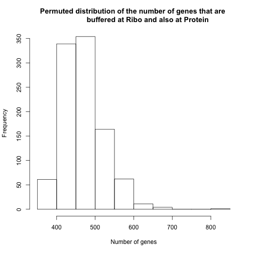

```r
buffer_tables <-
    lapply(1:length(permute_labels),
        function(per_permute) {

      buffer_matrix_per_permute <- matrix(0, 2, 2)
      direction_per_permute <- direction_list_permute[[per_permute]]
      sig_per_permute <- sig_list_permute[[per_permute]]

      # Buffering at ribo and protein
      buffer_matrix_per_permute[1,1] <-
          sum(direction_per_permute$ii_rnaGTpro_per_permute &
              sig_per_permute$ii_sig_rnapro_per_permute &
              direction_per_permute$ii_rnaGTribo_per_permute &
              sig_per_permute$ii_sig_rnaribo_per_permute)

      # Non-buffered at Ribo and buffered at Protein
      buffer_matrix_per_permute[2,1] <-
          sum(direction_per_permute$ii_rnaGTpro_per_permute &
              sig_per_permute$ii_sig_rnapro_per_permute &
              direction_per_permute$ii_riboGTrna_per_permute &
              sig_per_permute$ii_sig_rnaribo_per_permute)


      # Buffered at Ribo and non-buffered at Protein
      buffer_matrix_per_permute[1,2] <-
          sum(direction_per_permute$ii_proGTrna_per_permute &
              sig_per_permute$ii_sig_rnapro_per_permute &
              direction_per_permute$ii_rnaGTribo_per_permute &
              sig_per_permute$ii_sig_rnaribo_per_permute)

      # Non-buffered at Ribo and non-buffered at Protein
      buffer_matrix_per_permute[2,2] <-
          sum(direction_per_permute$ii_proGTrna_per_permute &
              sig_per_permute$ii_sig_rnapro_per_permute &
              direction_per_permute$ii_riboGTrna_per_permute &
              sig_per_permute$ii_sig_rnaribo_per_permute)
      return(buffer_matrix_per_permute)
    })

hist( sapply(buffer_tables,
            function(single_table) single_table[1,1]),
      main = "Permuted distribution of the number of genes that are
              buffered at Ribo and also at Protein",
      xlab = "Number of genes")
```

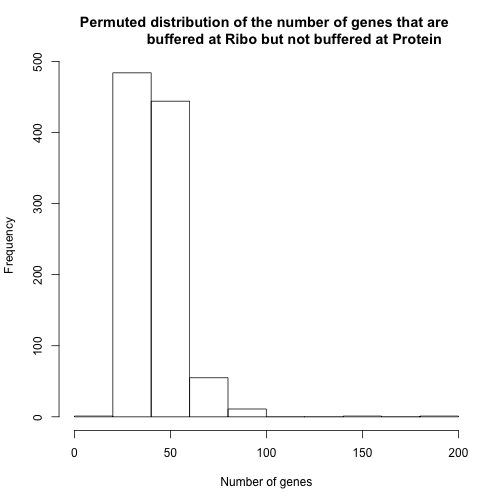

```r
hist( sapply(buffer_tables,
            function(single_table) single_table[1,2]),
      main = "Permuted distribution of the number of genes that are
              buffered at Ribo but not buffered at Protein",
      xlab = "Number of genes")
```

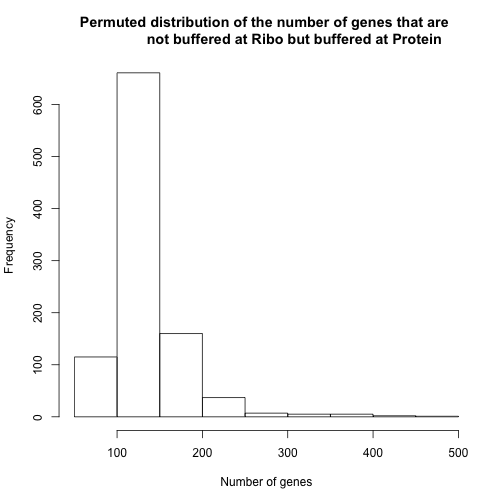

```r
hist( sapply(buffer_tables,
            function(single_table) single_table[2,1]),
      main = "Permuted distribution of the number of genes that are
              not buffered at Ribo but buffered at Protein",
      xlab = "Number of genes")
```

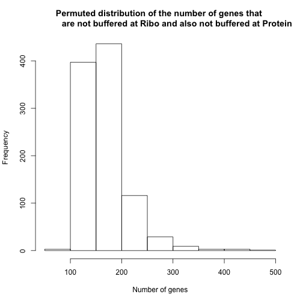

```r
hist( sapply(buffer_tables,
            function(single_table) single_table[2,2]),
      main = "Permuted distribution of the number of genes that
              are not buffered at Ribo and also not buffered at Protein",
      xlab = "Number of genes")
```

# Permuted p-values

## Buffering considering interaction effect

```r
load(file.path(rdadir,"TEnew.rda"))

## load LRT results of RNA vs. Protein divergence
load(file.path(rdadir,"rnapro.rda"))


## Compute fold changes based on un-normalized data
## from the object eSetRRP.log2 in eSetRRP.rda
load( file.path(rdadir,"eSetRRP.rda") )

eSet.temp <- eSetRRP.log2[ ,eSetRRP.log2$species!="rhesus"]

fc.mat <- lapply( seq_along( c("human","chimp") ), function(i) {
  ii <- eSet.temp$species == c("human","chimp")[i]
  eSet.tt <- eSet.temp[, ii]
  emat <- lapply( seq_along( c("ribo","rna","protein") ), function(j) {
    jj <- eSet.tt$seqData == c("ribo","rna","protein")[j]
    rowMeans( exprs(eSet.tt[, jj] ), na.rm=TRUE )
  })
  emat <- do.call(cbind, emat)
  colnames(emat) <- c("ribo","rna","protein")
  return( data.frame(emat) )
})
names(fc.mat) <- c("human","chimp")

dmat_unnormed <- data.frame( ribo = fc.mat$human$ribo-fc.mat$chimp$ribo,
                             rna = fc.mat$human$rna-fc.mat$chimp$rna,
                             pro = fc.mat$human$protein-fc.mat$chimp$protein )

xy.rnapro <- data.frame( rna = dmat_unnormed$rna,
                         pro = dmat_unnormed$pro )
xy.riborna <- data.frame( rna = dmat_unnormed$rna,
                          ribo = dmat_unnormed$ribo )
xy.ribopro <- data.frame( ribo = dmat_unnormed$ribo,
                          pro = dmat_unnormed$pro )

# RNA-Ribo divergence
# Genes with sig. human/chimp difference in divergence between RNA and Ribo
ii_sig_rnaribo <- res.riborna$int.qval < .01
# Genes with RNA > Ribo in effect sizes
ii_rnaGTribo <- abs(xy.riborna$rna) > abs(xy.riborna$ribo)
# Genes with RNA < Ribo in effect sizes
ii_riboGTrna <- abs(xy.riborna$ribo) > abs(xy.riborna$rna)

# RNA-protein divergence
# Genes with sig. human/chimp difference in divergence between RNA and protein
ii_sig_rnapro <- res.rnapro$int.qval < .01
# Genes with RNA > Protein in effect sizes
ii_rnaGTpro <- abs(xy.rnapro$rna) > abs(xy.rnapro$pro)
# Genes with RNA < Protein in effect sizes
ii_proGTrna <- abs(xy.rnapro$pro) > abs(xy.rnapro$rna)


# Observed table
buffering_matrix_interact <-
    matrix(0, 2, 2,
     dimnames = list(rnaribo = c("Ribo buffered", "Ribo non-buffered"),
                   rnapro = c("Protein buffered", "Protein non-buffered") ) )

buffering_matrix_interact[1,1] <-
    sum( (ii_rnaGTpro & ii_sig_rnapro)[ii_rnaGTribo & ii_sig_rnaribo])
buffering_matrix_interact[1,2] <-
    sum( (ii_proGTrna & ii_sig_rnapro)[ii_rnaGTribo & ii_sig_rnaribo])
buffering_matrix_interact[2,1] <-
    sum( (ii_rnaGTpro & ii_sig_rnapro)[ii_riboGTrna & ii_sig_rnaribo])
buffering_matrix_interact[2,2] <-
    sum( (ii_proGTrna & ii_sig_rnapro)[ii_riboGTrna & ii_sig_rnaribo])
```

Proportion of genes buffered at both Ribo and Protein level among genes that are buffered in Protein

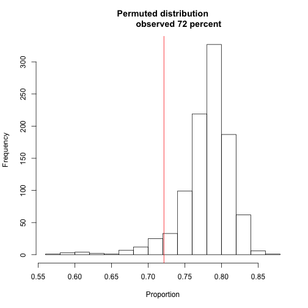

```r
require(matrixStats)

observed_pro <- buffering_matrix_interact[1,1]/colSums(buffering_matrix_interact)[1]
null_pro <- sapply(buffer_tables,
                    function(per_table) {
                    per_table[1,1]/colSums(per_table)[1]
                    })
hist(null_pro,
     main = paste("Permuted distribution
             observed", round(observed_pro,2)*100, "percent"), xlab = "Proportion")
abline( v = observed_pro, col = "red")
```

```r
ntests <- pmin(sum(!is.na(null_pro)), length(null_pro))
permute_pval <- pmax(sum(null_pro > observed_pro, na.rm = TRUE)/ntests,
                     1/ntests)
permute_pval
```

```r
## [1] 0.9433771
```

Proportion of genes buffered at both Ribo and Protein level among genes that are buffered in Ribo

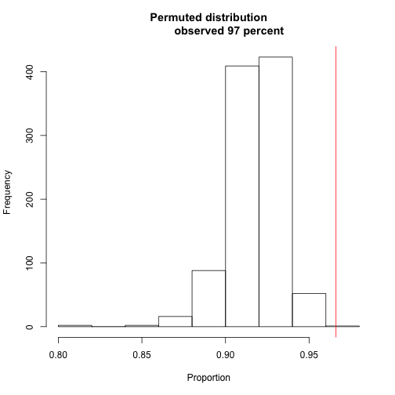

```r
require(matrixStats)

observed_ribo <- buffering_matrix_interact[1,1]/rowSums(buffering_matrix_interact)[1]
null_ribo <- sapply(buffer_tables,
                    function(per_table) {
                    per_table[1,1]/rowSums(per_table)[1]
                    })
hist(null_ribo,
     main = paste("Permuted distribution
             observed", round(observed_ribo,2)*100, "percent"), xlab = "Proportion")
abline( v = observed_ribo, col = "red")
```

```r
ntests <- pmin(sum(!is.na(null_ribo)), length(null_ribo))
permute_pval <- pmax(sum(null_ribo > observed_ribo, na.rm = TRUE)/ntests,
                     1/ntests)
permute_pval
```

```r
## [1] 0.001007049
```

## Buffering NOT considering interaction effect

```r
load(file.path(rdadir,"TEnew.rda"))

## load LRT results of RNA vs. Protein divergence
load(file.path(rdadir,"rnapro.rda"))


## Compute fold changes based on un-normalized data
## from the object eSetRRP.log2 in eSetRRP.rda
load( file.path(rdadir,"eSetRRP.rda") )

eSet.temp <- eSetRRP.log2[ ,eSetRRP.log2$species!="rhesus"]

fc.mat <- lapply( seq_along( c("human","chimp") ), function(i) {
  ii <- eSet.temp$species == c("human","chimp")[i]
  eSet.tt <- eSet.temp[, ii]
  emat <- lapply( seq_along( c("ribo","rna","protein") ), function(j) {
    jj <- eSet.tt$seqData == c("ribo","rna","protein")[j]
    rowMeans( exprs(eSet.tt[, jj] ), na.rm=TRUE )
  })
  emat <- do.call(cbind, emat)
  colnames(emat) <- c("ribo","rna","protein")
  return( data.frame(emat) )
})
names(fc.mat) <- c("human","chimp")

dmat_unnormed <- data.frame( ribo = fc.mat$human$ribo-fc.mat$chimp$ribo,
                             rna = fc.mat$human$rna-fc.mat$chimp$rna,
                             pro = fc.mat$human$protein-fc.mat$chimp$protein )

xy.rnapro <- data.frame( rna = dmat_unnormed$rna,
                         pro = dmat_unnormed$pro )
xy.riborna <- data.frame( rna = dmat_unnormed$rna,
                          ribo = dmat_unnormed$ribo )
xy.ribopro <- data.frame( ribo = dmat_unnormed$ribo,
                          pro = dmat_unnormed$pro )

# RNA-Ribo divergence
# Genes with sig. human/chimp difference in divergence between RNA and Ribo
ii_sig_rnaribo <- res.riborna$int.qval < .01
# Genes with RNA > Ribo in effect sizes
ii_rnaGTribo <- abs(xy.riborna$rna) > abs(xy.riborna$ribo)
# Genes with RNA < Ribo in effect sizes
ii_riboGTrna <- abs(xy.riborna$ribo) > abs(xy.riborna$rna)

# RNA-protein divergence
# Genes with sig. human/chimp difference in divergence between RNA and protein
ii_sig_rnapro <- res.rnapro$int.qval < .01
# Genes with RNA > Protein in effect sizes
ii_rnaGTpro <- abs(xy.rnapro$rna) > abs(xy.rnapro$pro)
# Genes with RNA < Protein in effect sizes
ii_proGTrna <- abs(xy.rnapro$pro) > abs(xy.rnapro$rna)
```

### Of genes with sig. translation efficiency

Proportion of genes buffered at both Ribo and Protein level among genes that are buffered in Ribo

```r
# Observed table
buffering_matrix <-
    matrix(0, 2, 2,
     dimnames = list(rnaribo = c("Ribo buffered", "Ribo non-buffered"),
                   rnapro = c("Protein buffered", "Protein non-buffered") ) )

buffering_matrix[1,1] <-
    sum( (ii_rnaGTpro & ii_rnaGTribo) & ii_sig_rnaribo)
buffering_matrix[1,2] <-
    sum( (ii_proGTrna & ii_rnaGTribo) & ii_sig_rnaribo)
buffering_matrix[2,1] <-
    sum( (ii_rnaGTpro & ii_riboGTrna) & ii_sig_rnaribo)
buffering_matrix[2,2] <-
    sum( (ii_proGTrna & ii_riboGTrna) & ii_sig_rnaribo)


# Permutation-based table
buffer_tables_riborna <-
    lapply(1:length(permute_labels),
        function(per_permute) {

      buffering_matrix_riborna <- matrix(0, 2, 2)
      direction_per_permute <- direction_list_permute[[per_permute]]
      sig_per_permute <- sig_list_permute[[per_permute]]

      # Buffering at ribo and protein
      buffering_matrix_riborna[1,1] <-
          sum(direction_per_permute$ii_rnaGTpro_per_permute &
              direction_per_permute$ii_rnaGTribo_per_permute &
              sig_per_permute$ii_sig_rnaribo_per_permute)

      # Non-buffered at Ribo and buffered at Protein
      buffering_matrix_riborna[2,1] <-
          sum(direction_per_permute$ii_rnaGTpro_per_permute &
              direction_per_permute$ii_riboGTrna_per_permute &
              sig_per_permute$ii_sig_rnaribo_per_permute)


      # Buffered at Ribo and non-buffered at Protein
      buffering_matrix_riborna[1,2] <-
          sum(direction_per_permute$ii_proGTrna_per_permute &
              direction_per_permute$ii_rnaGTribo_per_permute &
              sig_per_permute$ii_sig_rnaribo_per_permute)

      # Non-buffered at Ribo and non-buffered at Protein
      buffering_matrix_riborna[2,2] <-
          sum(direction_per_permute$ii_proGTrna_per_permute &
              direction_per_permute$ii_riboGTrna_per_permute &
              sig_per_permute$ii_sig_rnaribo_per_permute)
      return(buffering_matrix_riborna)
    })
```

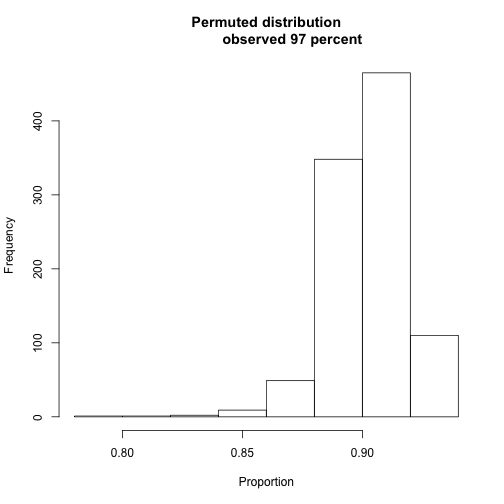

```r
require(matrixStats)

observed_riborna <- buffering_matrix[1,1]/rowSums(buffering_matrix)[1]
null_riborna <- sapply(buffer_tables_riborna,
                        function(per_table) {
                        per_table[1,1]/rowSums(per_table)[1]
                        })
hist(null_riborna,
     main = paste("Permuted distribution
             observed", round(observed_riborna,2)*100, "percent"),
     xlab = "Proportion")
abline( v = observed_riborna, col = "red")
```

```r
ntests <- pmin(sum(!is.na(null_riborna)), length(null_riborna))
permute_pval <- pmax(sum(null_riborna > observed_riborna, na.rm = TRUE)/ntests,
                     1/ntests)
permute_pval
```

```r
## [1] 0.001015228
```

### Of genes with sig. RNA-protein interaction

Proportion of genes buffered at both Ribo and Protein level among genes that are buffered in Protein

```r
# Observed table
buffering_matrix_rnapro <-
    matrix(0, 2, 2,
     dimnames = list(rnaribo = c("Ribo buffered", "Ribo non-buffered"),
                   rnapro = c("Protein buffered", "Protein non-buffered") ) )

buffering_matrix_rnapro[1,1] <-
    sum( (ii_rnaGTpro & ii_rnaGTribo) & ii_sig_rnapro)
buffering_matrix_rnapro[1,2] <-
    sum( (ii_proGTrna & ii_rnaGTribo) & ii_sig_rnapro)
buffering_matrix_rnapro[2,1] <-
    sum( (ii_rnaGTpro & ii_riboGTrna) & ii_sig_rnapro)
buffering_matrix_rnapro[2,2] <-
    sum( (ii_proGTrna & ii_riboGTrna) & ii_sig_rnapro)


# Permutation-based table
buffer_tables_rnapro_permute <-
    lapply(1:length(permute_labels),
        function(per_permute) {

      buffering_matrix_rnapro <- matrix(0, 2, 2)
      direction_per_permute <- direction_list_permute[[per_permute]]
      sig_per_permute <- sig_list_permute[[per_permute]]

      # Buffering at ribo and protein
      buffering_matrix_rnapro[1,1] <-
          sum(direction_per_permute$ii_rnaGTpro_per_permute &
              direction_per_permute$ii_rnaGTribo_per_permute &
              sig_per_permute$ii_sig_rnapro_per_permute)

      # Non-buffered at Ribo and buffered at Protein
      buffering_matrix_rnapro[2,1] <-
          sum(direction_per_permute$ii_rnaGTpro_per_permute &
              direction_per_permute$ii_riboGTrna_per_permute &
              sig_per_permute$ii_sig_rnapro_per_permute)


      # Buffered at Ribo and non-buffered at Protein
      buffering_matrix_rnapro[1,2] <-
          sum(direction_per_permute$ii_proGTrna_per_permute &
              direction_per_permute$ii_rnaGTribo_per_permute &
              sig_per_permute$ii_sig_rnapro_per_permute)

      # Non-buffered at Ribo and non-buffered at Protein
      buffering_matrix_rnapro[2,2] <-
          sum(direction_per_permute$ii_proGTrna_per_permute &
              direction_per_permute$ii_riboGTrna_per_permute &
              sig_per_permute$ii_sig_rnapro_per_permute)
      return(buffering_matrix_rnapro)
    })
```

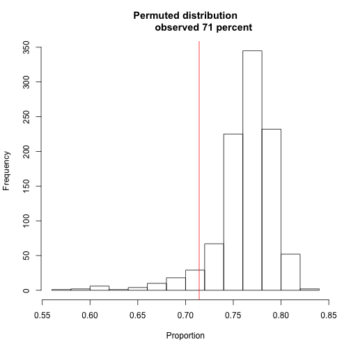

```r
require(matrixStats)

observed_rnapro <- buffering_matrix_rnapro[1,1]/colSums(buffering_matrix_rnapro)[1]
null_rnapro <- sapply(buffer_tables_rnapro_permute,
                        function(per_table) {
                        per_table[1,1]/colSums(per_table)[1]
                        })
hist(null_rnapro,
     main = paste("Permuted distribution
             observed", round(observed_rnapro,2)*100, "percent"),
     xlab = "Proportion")
abline( v = observed_rnapro, col = "red")
```

```r
ntests <- pmin(sum(!is.na(null_rnapro)), length(null_rnapro))
permute_pval <- pmax(sum(null_rnapro > observed_rnapro, na.rm = TRUE)/ntests,
                     1/ntests)
permute_pval
```

```r
## [1] 0.9406439
```

```r
## R version 3.2.1 (2015-06-18)
## Platform: x86_64-apple-darwin13.4.0 (64-bit)
## Running under: OS X 10.10.4 (Yosemite)
##
## locale:
## [1] en_US.UTF-8/en_US.UTF-8/en_US.UTF-8/C/en_US.UTF-8/en_US.UTF-8
##
## attached base packages:
## [1] parallel  stats     graphics  grDevices utils     datasets  methods
## [8] base
##
## other attached packages:
## [1] matrixStats_0.14.2  Humanzee_0.0.0.9000 devtools_1.9.0
## [4] broman_0.59-5       Biobase_2.28.0      BiocGenerics_0.14.0
## [7] knitr_1.11
##
## loaded via a namespace (and not attached):
##  [1] digest_0.6.8         assertthat_0.1       mime_0.4
##  [4] knitrBootstrap_1.0.0 formatR_1.2          magrittr_1.5
##  [7] evaluate_0.7.2       stringi_0.5-5        rmarkdown_0.8
## [10] tools_3.2.1          stringr_1.0.0        markdown_0.7.7
## [13] yaml_2.1.13          memoise_0.2.1        htmltools_0.2.6
```

Styled with knitrBootstrap